# Reproducible Research (course project 1)

## Loading and preprocessing the data

Reading the dataset activity.csv, containing the variables

- steps: Number of steps taken in a 5-minute interval
- date: The date on which the measurement was taken
- interval: Identifier for the 5-minute interval in which the measurement was taken

code:

```r
kolom = c("integer", "character", "integer")
actdf <- read.csv("activity.csv", head=TRUE, colClasses=kolom, na.strings="NA")

head(actdf)
```

```
##   steps       date interval
## 1    NA 2012-10-01        0
## 2    NA 2012-10-01        5
## 3    NA 2012-10-01       10
## 4    NA 2012-10-01       15
## 5    NA 2012-10-01       20
## 6    NA 2012-10-01       25
```

Processing the dataset: set date column in correct form and remove rows with missing values

```r
actdf$date <- as.Date(actdf$date)
actdfclean <- subset(actdf, !is.na(actdf$steps))
```

## What is the mean total number of steps taken per day?

Calculating the total number of steps taken each day Presented in a Histogram

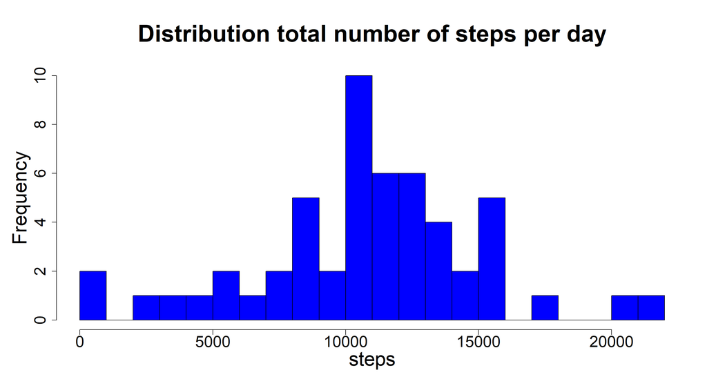

```r
dailytotal <- tapply(actdfclean$steps, actdfclean$date, sum, na.rm=TRUE)
dailytotal <- dailytotal[!is.na(dailytotal)]

par(cex.main=3, cex.lab=2.5, cex.axis=2, mar=c(5,6,7,2))
hist(x=dailytotal, col="blue", breaks=25, xlab="steps", ylab="Frequency", main="Distribution total number of steps per day")
```

The mean and median total number of steps taken per day

```r
m <- mean(dailytotal)
m = as.integer(m)
med <- median(dailytotal)
med = as.integer(med)
```

The mean is **10766**  
The median is **10765**

## What is the average daily pattern?

To show the average daily pattern, a time series plot of the 5-minute interval(x-axis) and the average number of steps taken, averaged across all days (y-axis) is plotted.

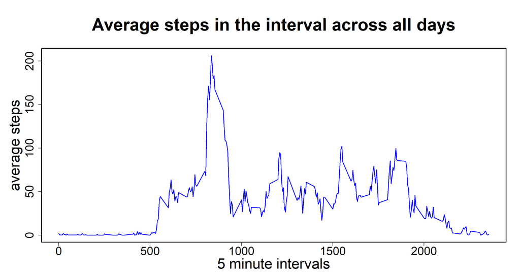

```r
average <- tapply(actdfclean$steps, actdfclean$interval, mean, na.rm=TRUE)
average_integer <- data.frame(interval=as.integer(names(average)), avg=average)

par(cex.main=3, cex.lab=2.5, cex.axis=2, mar=c(5,6,7,2), lwd=2)
with(average_integer, plot(interval, avg, type="l", col="blue", xlab="5 minute intervals", ylab="average steps", main="Average steps in the interval across all days"))
```

Calculate which 5-minute interval, on average across all the days in the dataset, contains the maximum number of steps

```r
max_steps <- max(average_integer$avg)
interval <- average_integer[average_integer$avg==max_steps,1]
max_steps <- round(max_steps, digits=1)
```

In the dataset at 5-minute interval **835** the maximum average of **206.2** steps is taken.

## Imputing missing values

Calculating the total number of rows with missing values coded as NA

```r
aantal<- sum(is.na(actdf$steps))
```

The original dataset has **2304** rows with missing data.

To fill the missing values in the dataset the mean is used for the 5-minute interval in which the data is missing.

```r
average <- tapply(actdfclean$steps, actdfclean$interval, mean, na.rm=TRUE)
dfimpute <- actdf
leeg <- is.na(dfimpute$steps)
dfimpute$steps[leeg] <- average[as.character(dfimpute$interval[leeg])]
```

Histogram of the total number of steps taken each day, corrected for missing values

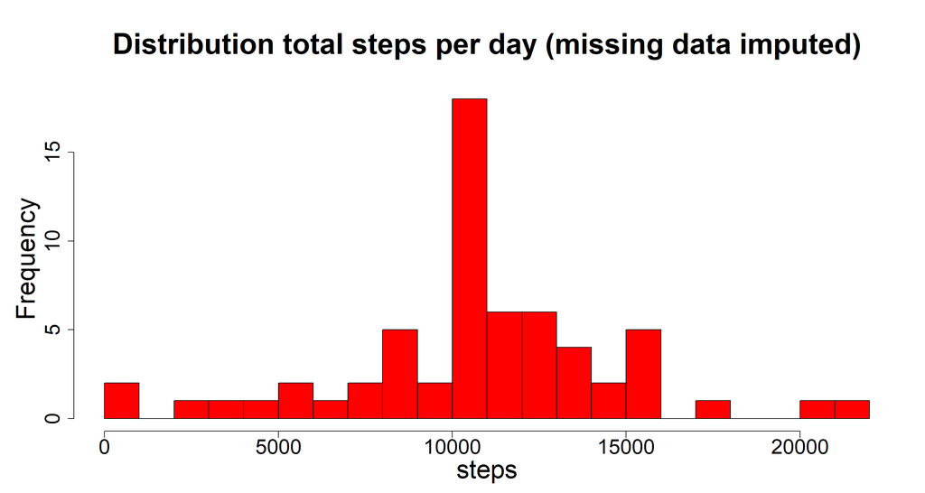

```r
correcteddailytotal <- tapply(dfimpute$steps, dfimpute$date, sum, na.rm=TRUE)
par(cex.main=2.8, cex.lab=2.5, cex.axis=2, mar=c(5,6,7,2))
hist(x=correcteddailytotal, col="red", breaks=25, xlab="steps", ylab="Frequency", main="Distribution total steps per day (missing data imputed)")
```

Calculating the mean and median total number of steps taken per day, with imputed data for missing values

```r
m <- mean(correcteddailytotal)
m = as.integer(m)
med <- median(correcteddailytotal)
med = as.integer(med)
```

The mean for the imputed dataset is **10766**  
The median for the imputed dataset is **10766**

## Are there differences in activity patterns between weekdays and weekends?

Creating a new factor vaiable in the dataset with two levels - “weekday” and “weekend”

```r
is_weekday<- function(d){
        wd <- weekdays(d)
        ifelse(wd=="zaterdag"|wd=="zondag","weekend","weekday")
}

wx <- sapply(dfimpute$date, is_weekday)
dfimpute$wk <- as.factor(wx)
head(dfimpute)
```

```
##       steps       date interval      wk
## 1 1.7169811 2012-10-01        0 weekday
## 2 0.3396226 2012-10-01        5 weekday
## 3 0.1320755 2012-10-01       10 weekday
## 4 0.1509434 2012-10-01       15 weekday
## 5 0.0754717 2012-10-01       20 weekday
## 6 2.0943396 2012-10-01       25 weekday
```

Panel plot containing a time series plot averaged across all weekday days or weekend days

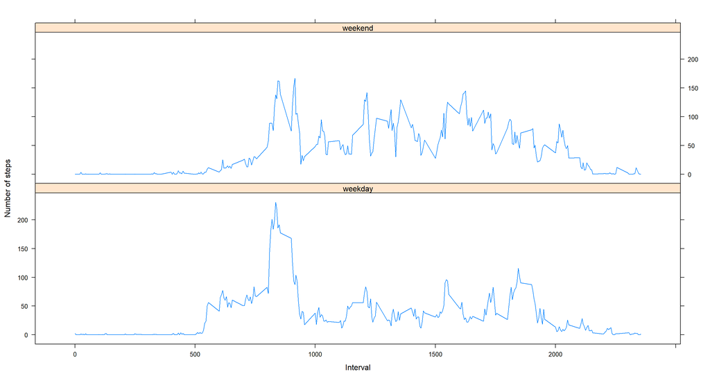

```r
wk_df <- aggregate(steps~wk + interval, data=dfimpute, FUN=mean)

library(lattice)
windows(width=15, height=15)
xyplot(steps~interval|factor(wk),
       layout=c(1,2),
       xlab="Interval",
       ylab="Number of steps",
       type="l",
       lty=1,
       data=wk_df)
```